# Data Camp Insights

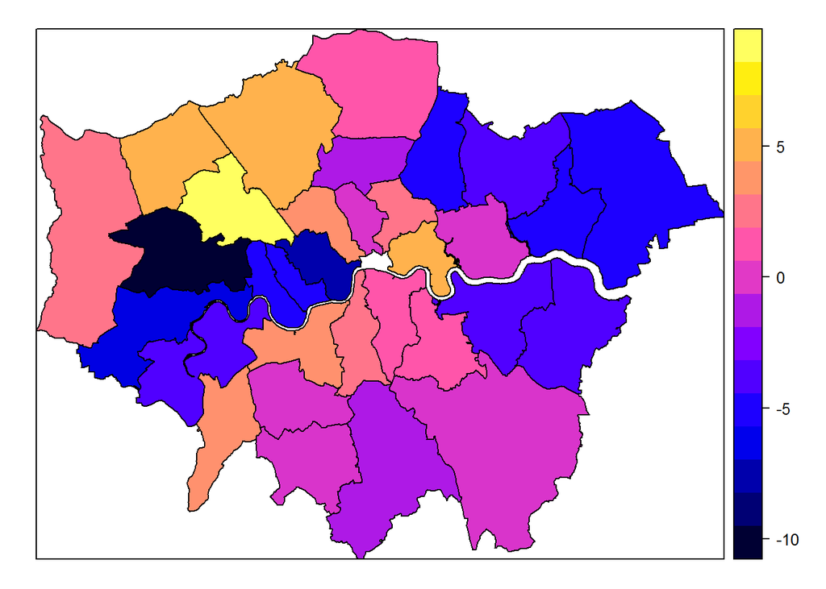

```r
# Put residuals into the spatial data.
london$Flu_Resid <- residuals(model_flu)

# Map the residuals using spplot
sp::spplot(london, "Flu_Resid")
```

```r
# A linear model should fit the data and leave uncorrelated residuals
# This applies to non-spatial models, where, for example, fitting a straight line through points on a curve would lead to serially-correlated residuals
# A model on spatial data should aim to have residuals that show no significant spatial correlation

# You can test the model fitted to the flu data using moran.mc() from the spdep package
# Monte Carlo Moran tests were previously discussed in the Spatial autocorrelation test exercise earlier in the chapter

# Compute the neighborhood structure.
borough_nb <- poly2nb(london)

# Test spatial correlation of the residuals.
moran.mc(london$Flu_Resid, listw = nb2listw(borough_nb), nsim = 999)
```

```
##
##  Monte-Carlo simulation of Moran I
##
## data:  london$Flu_Resid
## weights: nb2listw(borough_nb)
## number of simulations + 1: 1000
##
## statistic = 0.15059, observed rank = 925, p-value = 0.075
## alternative hypothesis: greater
```

```r
# Bayesian statistical models return samples of the parameters of interest (the "posterior" distribution) based on some "prior" distribution which is then updated by the data
# The Bayesian modelling process returns a number of samples from which you can compute the mean, or an exceedence probability, or any other quantity you might compute from a distribution

# Before you fit a model with spatial correlation, you'll first fit the same model as before, but using Bayesian inference

# The london data set has been loaded
# The R2BayesX package provides an interface to the BayesX code.

# The syntax for bayesx() is similar, but the offset has to be specified explicitly from the data frame, the family name is in quotes, and the spatial data frame needs to be turned into a plain data frame
# Run the model fitting and inspect with summary()

# Plot the samples from the Bayesian model
# On the left is the "trace" of samples in sequential order, and on the right is the parameter density
# For this model there is an intercept and a slope for the Health Deprivation score
# The parameter density should correspond with the parameter summary

# Use R2BayesX (called at top of routine)
# library(R2BayesX)

# Fit a GLM
model_flu <- glm(Flu_OBS ~ HealthDeprivation, offset = log(TOTAL_POP),
                data = london, family = poisson)

# Summarize it
summary(model_flu)
```

```
##
## Call:
## glm(formula = Flu_OBS ~ HealthDeprivation, family = poisson,
##     data = london, offset = log(TOTAL_POP))
##
## Deviance Residuals:
##     Min       1Q   Median       3Q      Max
## -9.5361  -4.5285  -0.0499   2.9043   8.2194
##
## Coefficients:
##                   Estimate Std. Error  z value Pr(>|z|)
## (Intercept)       -8.78190    0.02869 -306.043   <2e-16 ***
## HealthDeprivation  0.65689    0.06797    9.665   <2e-16 ***
## ---
## Signif. codes:  0 '***' 0.001 '**' 0.01 '*' 0.05 '.' 0.1 ' ' 1
##
## (Dispersion parameter for poisson family taken to be 1)
##
##     Null deviance: 703.75  on 31  degrees of freedom
## Residual deviance: 605.03  on 30  degrees of freedom
## AIC: 762.37
##
## Number of Fisher Scoring iterations: 5
```

```r
# Calculate coeff confidence intervals
confint(model_flu)
```

```
##                       2.5 %     97.5 %
## (Intercept)       -8.838677 -8.7261843
## HealthDeprivation  0.524437  0.7908841
```

```r
# Fit a Bayesian GLM
bayes_flu <- bayesx(Flu_OBS ~ HealthDeprivation, offset = log(london$TOTAL_POP),
                    family = "poisson", data = as.data.frame(london),
                    control = bayesx.control(seed = 17610407))

# Summarize it
summary(bayes_flu)
```

```
## Call:
## bayesx(formula = Flu_OBS ~ HealthDeprivation, data = as.data.frame(london),
##     offset = log(london$TOTAL_POP), control = bayesx.control(seed = 17610407),
##     family = "poisson")
##
## Fixed effects estimation results:
##
## Parametric coefficients:
##                      Mean      Sd    2.5%     50%   97.5%
## (Intercept)       -8.7831  0.0278 -8.8371 -8.7841 -8.7263
## HealthDeprivation  0.6592  0.0659  0.5345  0.6587  0.7900
##
## N = 32  burnin = 2000  method = MCMC  family = poisson
## iterations = 12000  step = 10
```

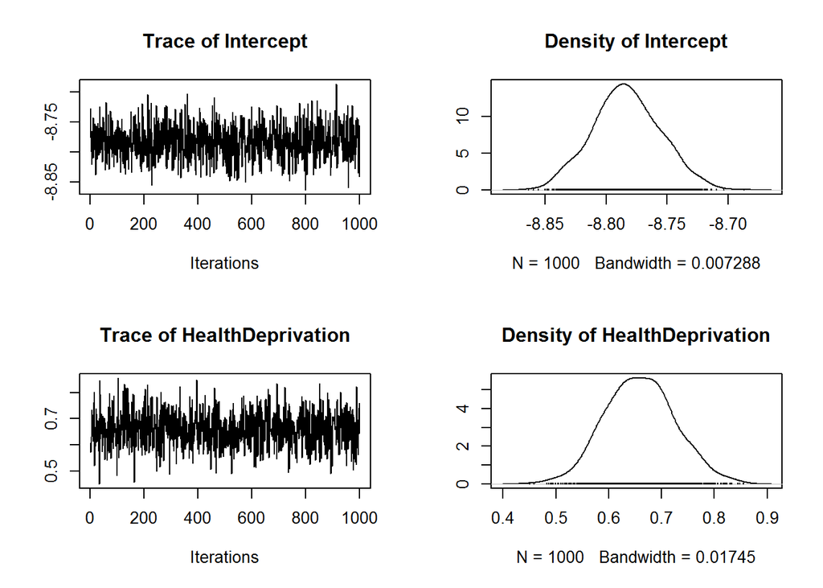

```r
# Look at the samples from the Bayesian model
plot(samples(bayes_flu))
```

```r
# You've fitted a non-spatial GLM with BayesX
# You can include a spatially correlated term based on the adjacency structure by adding a term to the formula specifying a spatially correlated model
# Use poly2nb() to compute the neighborhood structure of london to an nb object
# R2BayesX uses its own objects for the adjacency. Convert the nb object to a gra object
# The sx function specifies additional terms to bayesx. Create a term using the "spatial" basis and the gra object for the boroughs to define the map
# Print a summary of the model object. You should see a table of coefficients for the parametric part of the model as in the previous exercise, and then a table of "Smooth terms variance" with one row for the spatial term
# Note that since BayesX can fit many different forms in its sx terms, most of which, like the spatial model here, cannot be simply expressed with a parameter or two
# This table shows the variance of the random effects - for further explanation consult a text on random effects modelling

# Compute adjacency objects
borough_nb <- poly2nb(london)
borough_gra <- nb2gra(borough_nb)

# Fit spatial model
flu_spatial <- bayesx(
  Flu_OBS ~ HealthDeprivation + sx(i, bs = "spatial", map = borough_gra),
  offset = log(london$TOTAL_POP),
  family = "poisson", data = data.frame(london),
  control = bayesx.control(seed = 17610407)
)
```

```
## Note: created new output directory 'C:/Users/Dave/AppData/Local/Temp/Rtmpa43JUL/bayesx1'!
```

```r
# Summarize the model
summary(flu_spatial)
```

```
## Call:
## bayesx(formula = Flu_OBS ~ HealthDeprivation + sx(i, bs = "spatial",
##     map = borough_gra), data = data.frame(london), offset = log(london$TOTAL_POP),
##     control = bayesx.control(seed = 17610407), family = "poisson")
##
## Fixed effects estimation results:
##
## Parametric coefficients:
##                      Mean      Sd    2.5%     50%   97.5%
## (Intercept)       -9.2311  0.1246 -9.4826 -9.2298 -9.0148
## HealthDeprivation  0.7683  0.5844 -0.3749  0.7775  1.7922
##
## Smooth terms variances:
##             Mean     Sd   2.5%    50%  97.5%    Min    Max
## sx(i):mrf 4.6381 1.6822 2.2851 4.3510 8.8104 1.6557 16.266
##
## N = 32  burnin = 2000  method = MCMC  family = poisson
## iterations = 12000  step = 10
```

```r
# As with glm, you can get the fitted values and residuals from your model using the fitted and residuals functions. bayesx models are a bit more complex, since you have the linear predictor and terms from sx elements, such as the spatially correlated term
# The summary function will show you information for the linear model terms and the smoothing terms in two separate tables
# The spatial term is called "sx(i):mrf" - standing for "Markov Random Field"

# Bayesian analysis returns samples from a distribution for our S(x) term at each of the London boroughs
# The fitted function from bayesx models returns summary statistics for each borough
# You'll just look at the mean of that distribution for now

# The model from the BayesX output is available as flu_spatial.

# Summarise the model
summary(flu_spatial)
```

```
## Call:
## bayesx(formula = Flu_OBS ~ HealthDeprivation + sx(i, bs = "spatial",
##     map = borough_gra), data = data.frame(london), offset = log(london$TOTAL_POP),
##     control = bayesx.control(seed = 17610407), family = "poisson")
##
## Fixed effects estimation results:
##
## Parametric coefficients:
##                      Mean      Sd    2.5%     50%   97.5%
## (Intercept)       -9.2311  0.1246 -9.4826 -9.2298 -9.0148
## HealthDeprivation  0.7683  0.5844 -0.3749  0.7775  1.7922
##
## Smooth terms variances:
##             Mean     Sd   2.5%    50%  97.5%    Min    Max
## sx(i):mrf 4.6381 1.6822 2.2851 4.3510 8.8104 1.6557 16.266
##
## N = 32  burnin = 2000  method = MCMC  family = poisson
## iterations = 12000  step = 10
```

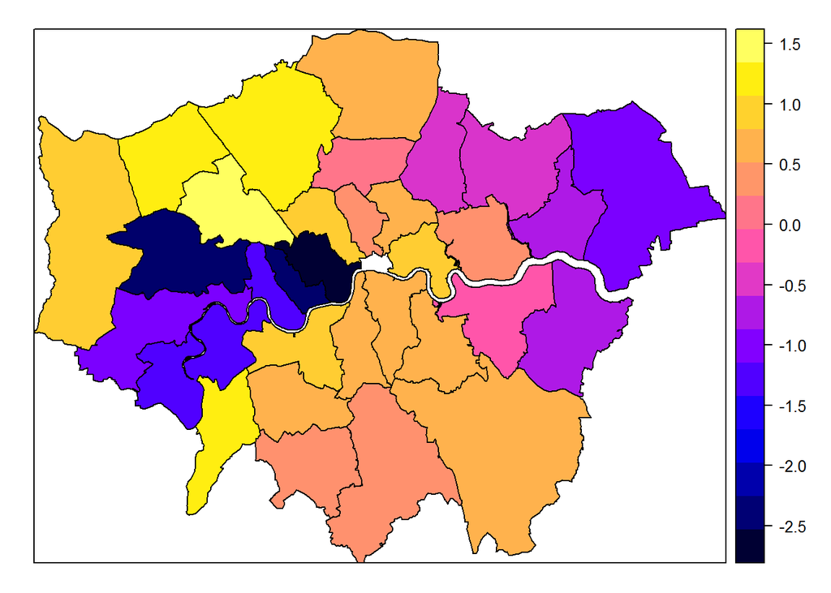

```r
# Map the fitted spatial term only
london$spatial <- fitted(flu_spatial, term = "sx(i):mrf")[, "Mean"]
sp::spplot(london, zcol = "spatial")
```

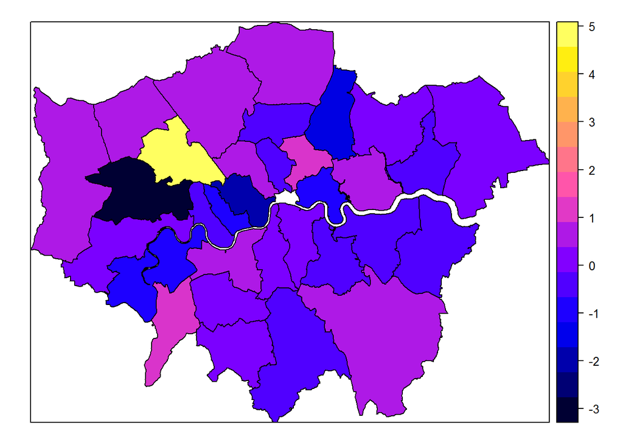

```r
# Map the residuals
london$spatial_resid <- residuals(flu_spatial)[, "mu"]
sp::spplot(london, zcol = "spatial_resid")
```

```r
# Test residuals for spatial correlation
moran.mc(london$spatial_resid, nb2listw(borough_nb), 999)
```

```
##
##  Monte-Carlo simulation of Moran I
##
## data:  london$spatial_resid
## weights: nb2listw(borough_nb)
## number of simulations + 1: 1000
##
## statistic = -0.26922, observed rank = 16, p-value = 0.984
## alternative hypothesis: greater
```

Chapter 4 - Geostatistics

Geostatistical data:

- The term “geostatistics” refers to a specific type of data, frequently of a specific format
  - The locations of the data (events) are typically not interesting; they just happen to be where a monitor was set up
  - Need to consider the variable - continuous (e.g., radiation), count (e.g., bacteria), boolean (e.g., presence of virus), etc.
- First, look for any large-scale trends, such as greater intensity to the northeast
  - Discontinuities? Need to add barriers if so
  - Always start by plotting a map, so that the type of model to create is based on EDA

Variogram:

- Objective is often to look at similarity of items relative to distance between items (variogram shows y=difference, x=distance)
  - Typically, the distance is the Pythagorean distance
  - Typically, the difference in the items is 0.5 * (Ax - Bx)**2 where Ax and Bx are a key measurement, x, applied to each of A and B
  - The variogram can tend to become computationally intense as well as overly dense due to its inclusion of every possible pair-pair combination
  - Can instead bin the x-axis and plot mean for the y-axis, which then forms the traditional variogram
- There are several interepretations that can be drawn from the variogram
  - If y increases with x, then there is a spatial correlation (near points are more similar than distant points)
  - If the slope of y vs. x flattens out at a certain distance, then that distance may be part of an asymptote (distances beyond the critical distance no longer drive extra differences)
  - The “nugget” variance is frequently defined as what you would expect to see if two observations are at zero distance from each either
- The Matern class of model is frequently favored for putting a functional form to the variogram

Kriging predictions:

- Kriging is the study of making predictions based on variograms and other geostatistical data
  - The basic maths are based on matrix multiplications, and are implemented in the gstat package
  - Outputs include the prediction and the variance (uncertainty) associated with the prediction
  - Can also look at various probabilities of exceedance given certain fixed parameters
- Can predict at just a single location, or over an entire grid

Automatic kriging:

- Sometimes need to bound the predictions (e.g., percentages between 0-1)
- May have different gradients by direction due to slopes of terrain or the like
- Kriging remains the best model currently available, despite some of the challenges and drawbacks
- Can automatically run krigining using the automap::autoKrige() command
  - Requires that variable can be treated as Gaussian
  - Need to check variogram to see that it is reasonable
  - Useful one-step tool for getting started on analysis

Wrap up:

- Spatial randomness
- Point patterns
- Aereal data
- Geostatistics

Example code includes:

```r
# Your job is to study the acidity (pH) of some Canadian survey data. The survey measurements are loaded into a spatial data object called ca_geo
# ca_geo has been pre-defined
ca_geo <- readRDS("./RInputFiles/ca_geo.RDS")
summary(ca_geo)
```

```
## Object of class SpatialPointsDataFrame
## Coordinates:
##         min       max
## x  542608.7  714269.2
## y 5541290.4 5652558.9
## Is projected: TRUE
## proj4string :
## [+init=epsg:32609 +proj=utm +zone=9 +datum=WGS84 +units=m +no_defs
## +ellps=WGS84 +towgs84=0,0,0]
## Number of points: 1140
## Data attributes:
##           ID            Elev             pH              Zn
##  102I881003:   1   Min.   :  5.0   Min.   :3.900   Min.   :  1.00
##  102I881004:   1   1st Qu.: 20.0   1st Qu.:6.100   1st Qu.: 40.00
##  102I881005:   1   Median :110.0   Median :6.600   Median : 62.00
##  102I881006:   1   Mean   :183.6   Mean   :6.531   Mean   : 72.34
##  102I881007:   1   3rd Qu.:310.0   3rd Qu.:7.000   3rd Qu.: 88.00
##  102I881008:   1   Max.   :914.0   Max.   :8.700   Max.   :510.00
##  (Other)   :1134   NA's   :9       NA's   :33
##        Cu                Pb                Ni               Co
##  Min.   :   1.00   Min.   :  1.000   Min.   :  1.00   Min.   : 1.00
##  1st Qu.:  21.00   1st Qu.:  1.000   1st Qu.:  7.00   1st Qu.:11.00
##  Median :  37.00   Median :  1.000   Median : 20.00   Median :19.00
##  Mean   :  57.45   Mean   :  2.975   Mean   : 27.85   Mean   :20.16
##  3rd Qu.:  76.00   3rd Qu.:  3.000   3rd Qu.: 37.00   3rd Qu.:27.00
##  Max.   :2950.00   Max.   :195.000   Max.   :340.00   Max.   :77.00
##
##        Ag               Mn               Fe               Mo
##  Min.   :0.1000   Min.   :   2.0   Min.   : 0.010   Min.   : 1.000
##  1st Qu.:0.1000   1st Qu.: 490.0   1st Qu.: 4.000   1st Qu.: 1.000
##  Median :0.1000   Median : 820.0   Median : 5.100   Median : 1.000
##  Mean   :0.1146   Mean   : 959.5   Mean   : 5.168   Mean   : 1.654
##  3rd Qu.:0.1000   3rd Qu.:1200.0   3rd Qu.: 6.200   3rd Qu.: 2.000
##  Max.   :7.9000   Max.   :9700.0   Max.   :24.000   Max.   :46.000
##
##        U               W               Sn                Hg
##  Min.   :-1.00   Min.   :-1.00   Min.   :  1.000   Min.   :    5
##  1st Qu.: 0.70   1st Qu.: 1.00   1st Qu.:  1.000   1st Qu.:   60
##  Median : 1.10   Median : 1.00   Median :  1.000   Median :   80
##  Mean   : 1.36   Mean   : 1.14   Mean   :  1.123   Mean   :  232
```

[output cut: 12 more lines]

```
##  Min.   :  2.0   Min.   :0.1000   Min.   :  5.0   Min.   :-1.00
##  1st Qu.:215.0   1st Qu.:0.1000   1st Qu.: 52.0   1st Qu.: 6.20
##  Median :295.0   Median :0.1000   Median : 88.0   Median : 9.20
##  Mean   :318.3   Mean   :0.1213   Mean   :114.1   Mean   :11.45
##  3rd Qu.:410.0   3rd Qu.:0.1000   3rd Qu.:148.0   3rd Qu.:14.00
##  Max.   :960.0   Max.   :4.2000   Max.   :860.0   Max.   :82.80
##
##        F               Au
##  Min.   : 20.0   Min.   :   1.00
##  1st Qu.:120.0   1st Qu.:   1.00
##  Median :150.0   Median :   2.00
##  Mean   :164.2   Mean   :  24.55
##  3rd Qu.:200.0   3rd Qu.:   5.00
##  Max.   :620.0   Max.   :5800.00
##
```

```r
str(ca_geo, 1)
```

```
## Formal class 'SpatialPointsDataFrame' [package "sp"] with 5 slots
```

```r
# See what measurements are at each location
names(ca_geo)
```

```
##  [1] "ID"   "Elev" "pH"   "Zn"   "Cu"   "Pb"   "Ni"   "Co"   "Ag"   "Mn"
## [11] "Fe"   "Mo"   "U"    "W"    "Sn"   "Hg"   "As"   "Sb"   "Ba"   "Cd"
## [21] "V"    "Bi"   "Cr"   "LoI"  "F"    "Au"
```

```r
# Get a summary of the acidity (pH) values
summary(ca_geo$pH)
```

```
##    Min. 1st Qu.  Median    Mean 3rd Qu.    Max.    NA's
##   3.900   6.100   6.600   6.531   7.000   8.700      33
```

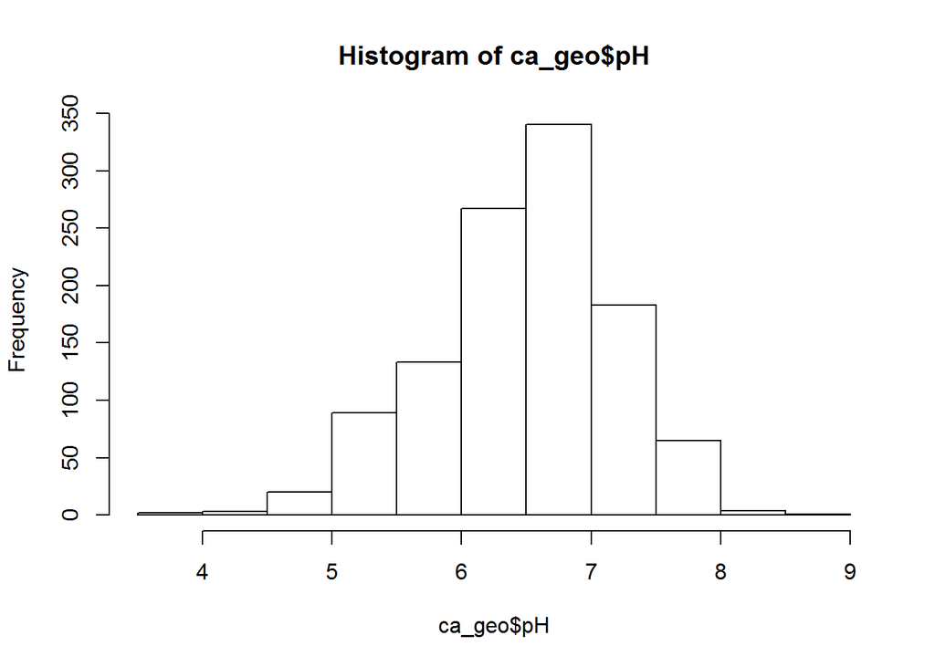

```r
# Look at the distribution
hist(ca_geo$pH)
```

```r
# Make a vector that is TRUE for the missing data
miss <- is.na(ca_geo$pH)
table(miss)
```

```
## miss
## FALSE  TRUE
##  1107    33
```

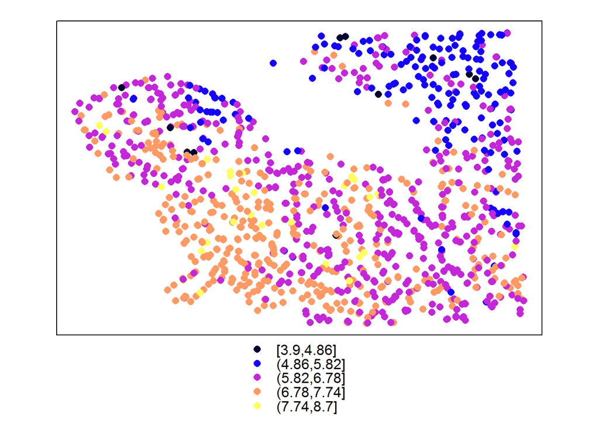

```r
# Plot a map of acidity
spplot(ca_geo[!miss, ], "pH")
```

```r
# The acidity data shows pH broadly increasing from north-east to south-west. Fitting a linear model with the coordinates as covariates will interpolate a flat plane through the values
# ca_geo has been pre-defined
str(ca_geo, 1)
```

```
## Formal class 'SpatialPointsDataFrame' [package "sp"] with 5 slots
```

```r
# Are they called lat-long, up-down, or what?
coordnames(ca_geo)
```

```
## [1] "x" "y"
```

```r
# Complete the formula
m_trend <- lm(pH ~ x + y, as.data.frame(ca_geo))

# Check the coefficients
summary(m_trend)
```

```
##
## Call:
## lm(formula = pH ~ x + y, data = as.data.frame(ca_geo))
##
## Residuals:
##      Min       1Q   Median       3Q      Max
## -2.83561 -0.32091 -0.00761  0.33188  2.06249
##
## Coefficients:
##               Estimate Std. Error t value Pr(>|t|)
## (Intercept)  8.358e+01  3.002e+00   27.84   <2e-16 ***
## x           -5.691e-06  3.483e-07  -16.34   <2e-16 ***
## y           -1.313e-05  5.319e-07  -24.68   <2e-16 ***
## ---
## Signif. codes:  0 '***' 0.001 '**' 0.01 '*' 0.05 '.' 0.1 ' ' 1
##
## Residual standard error: 0.5299 on 1104 degrees of freedom
##   (33 observations deleted due to missingness)
## Multiple R-squared:  0.4237, Adjusted R-squared:  0.4227
## F-statistic: 405.9 on 2 and 1104 DF,  p-value: < 2.2e-16
```

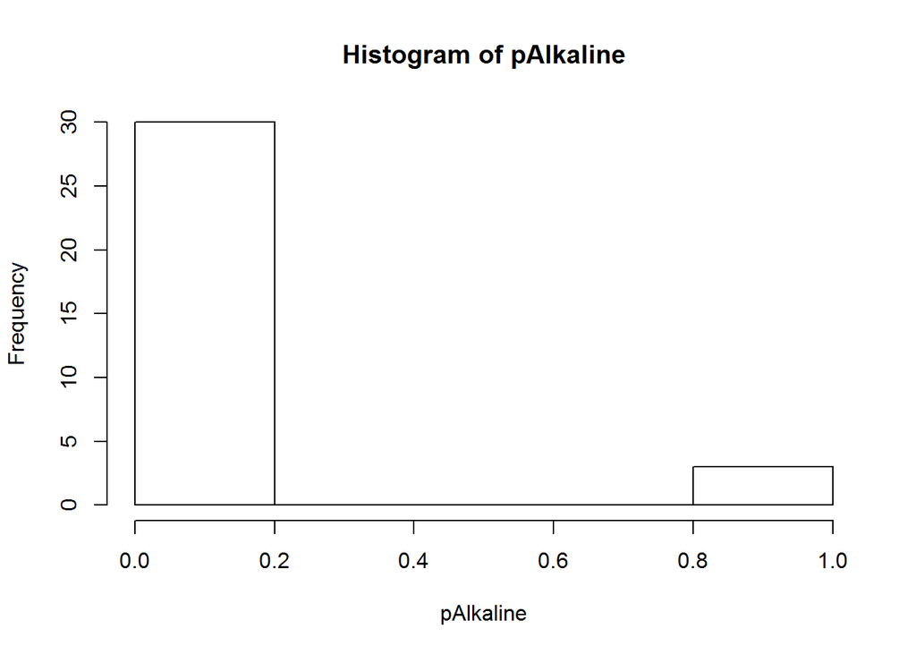

```r
# Your next task is to compute the pH at the locations that have missing data in the source. You can use the predict() function on the fitted model from the previous exercise for this
# ca_geo, miss, m_trend have been pre-defined
# ls.str()

# Make a vector that is TRUE for the missing data
miss <- is.na(ca_geo$pH)

# Create a data frame of missing data
ca_geo_miss <- as.data.frame(ca_geo)[miss, ]

# Predict pH for the missing data
predictions <- predict(m_trend, newdata = ca_geo_miss, se.fit = TRUE)

# Compute the exceedence probability
pAlkaline <- 1 - pnorm(7, mean = predictions$fit, sd = predictions$se.fit)
hist(pAlkaline)
```

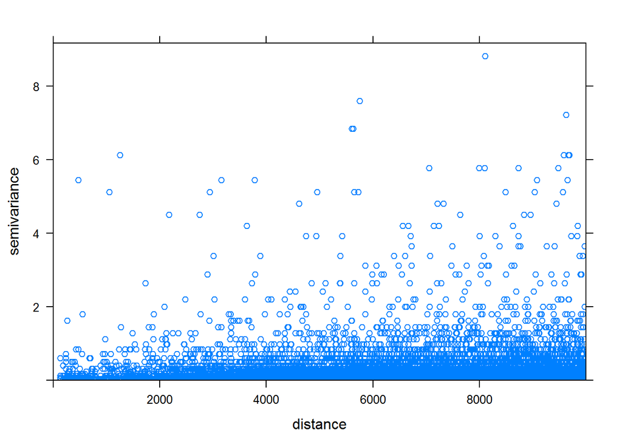

```r
# You can use the gstat package to plot variogram clouds and the variograms from data. Recall:
# The variogram cloud shows the differences of the measurements against distance for all pairs of data points
# The binned variogram divides the cloud into distance bins and computes the average difference within each bin
# The y-range of the binned variogram is always much smaller than the variogram cloud because the cloud includes the full range of values that go into computing the mean for the binned variogram

# The acidity survey data, ca_geo and the missing value index, miss have been pre-defined

# The gstat variogram() function uses the cloud argument to plot a variogram cloud - the default cloud parameter is FALSE

# ca_geo, miss have been pre-defined
# ls.str()

# Make a cloud from the non-missing data up to 10km
plot(gstat::variogram(pH ~ 1, ca_geo[!miss, ], cloud = TRUE, cutoff = 10000))
```

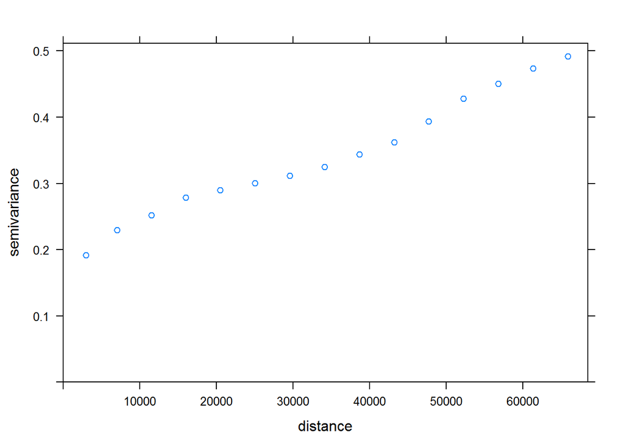

```r
# Make a variogram of the non-missing data
plot(gstat::variogram(pH ~ 1, ca_geo[!miss, ]))
```

```r
# You might imagine that if soil at a particular point is alkaline, then soil one metre away is likely to be alkaline too
# But can you say the same thing about soil one kilometre away, or ten kilometres, or one hundred kilometres?

# The shape of the previous variogram tells you there is a large-scale trend in the data
# You can fit a variogram considering this trend with gstat
# This variogram should flatten out, indicating there is no more spatial correlation after a certain distance with the trend taken into account

# ca_geo, miss have been pre-defined
# ls.str()

# See what coordinates are called
coordnames(ca_geo)
```

```
## [1] "x" "y"
```

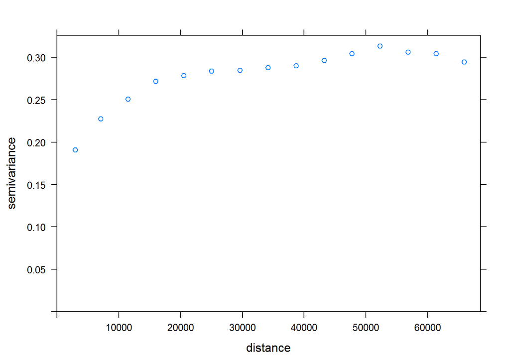

```r
# The pH depends on the coordinates
ph_vgm <- gstat::variogram(pH ~ x + y, ca_geo[!miss, ])
plot(ph_vgm)
```

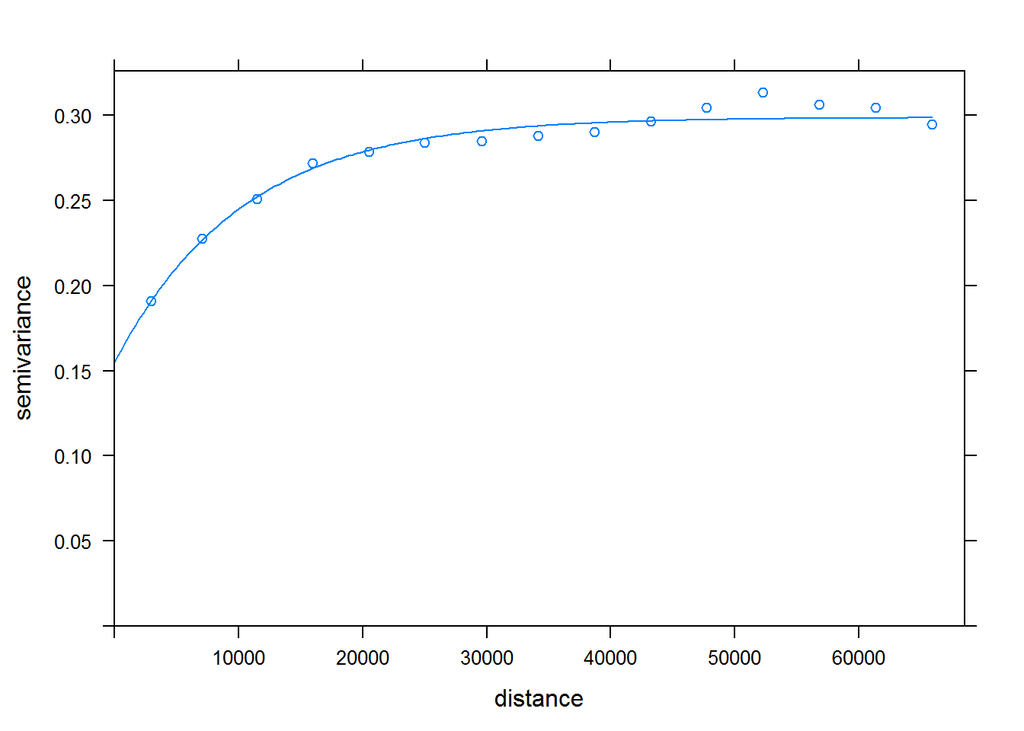

```r
# Next you'll fit a model to your variogram
# The gstat function fit.variogram() does this
# You need to give it some initial values as a starting point for the optimization algorithm to fit a better model

# The sill is the the upper limit of the model
# That is, the long-range largest value, ignoring any outliers

# A variogram has been plotted for you, and ph_vgm has been pre-defined
# Estimate some parameters by eyeballing the plot
# The nugget is the value of the semivariance at zero distance.
# The partial sill, psill is the difference between the sill and the nugget.
# Set the range to the distance at which the variogram has got about half way between the nugget and the sill

# Fit a variogram model by calling fit.variogram()
# The second argument should take the parameters you estimated, wrapped in a call to vgm()

# ca_geo, miss, ph_vgm have been pre-defined
# ls.str()

# Eyeball the variogram and estimate the initial parameters
nugget <- 0.16
psill <- 0.15
range <- 10000

# Fit the variogram
v_model <- gstat::fit.variogram(
  ph_vgm,
  model = gstat::vgm(
    model = "Ste",
    nugget = nugget,
    psill = psill,
    range = range,
    kappa = 0.5
  )
)

# Show the fitted variogram on top of the binned variogram
plot(ph_vgm, model = v_model)
```

```r
print(v_model)
```

```
##   model     psill    range kappa
## 1   Nug 0.1545116     0.00   0.0
## 2   Ste 0.1442007 14379.29   0.5
```

```r
# The final part of geostatical estimation is kriging itself
# This is the application of the variogram along with the sample data points to produce estimates and uncertainties at new locations

# The computation of estimates and uncertainties, together with the assumption of a normal (Gaussian) response means you can compute any function of the estimates - for example the probability of a new location having alkaline soil

# The acidity survey data, ca_geo, the missing value index, miss, and the variogram model, v_model, have been pre-defined

# ca_geo, miss, v_model have been pre-defined
# ls.str()

# Set the trend formula and the new data
km <- gstat::krige(pH ~ x + y, ca_geo[!miss, ], newdata = ca_geo[miss, ], model = v_model)
```

```
## [using universal kriging]
```

```r
names(km)
```

```
## [1] "var1.pred" "var1.var"
```

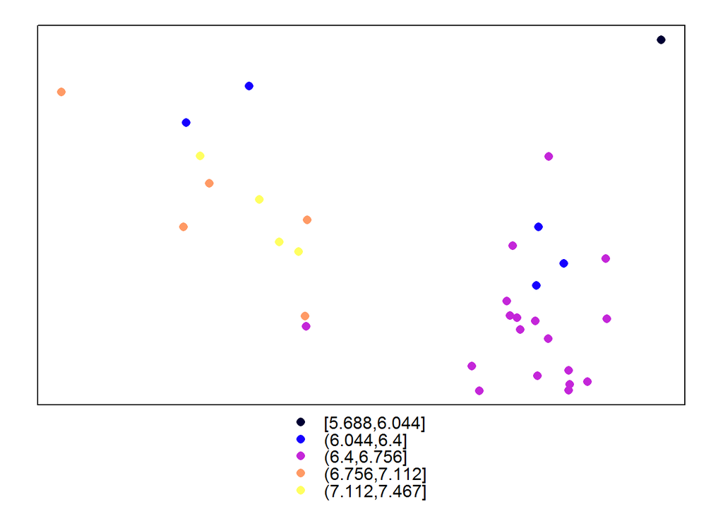

```r
# Plot the predicted values
spplot(km, "var1.pred")
```

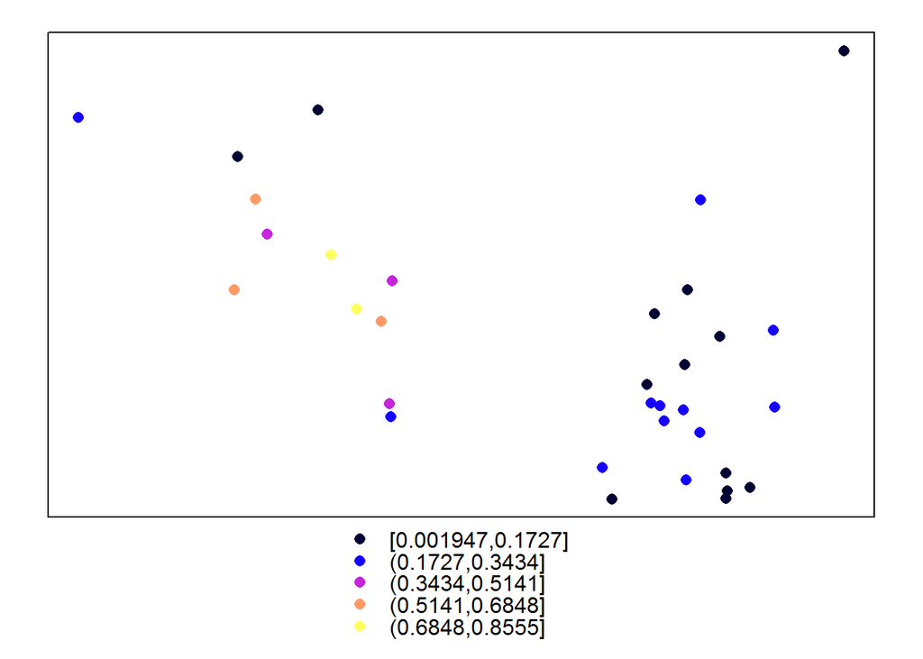

```r
# Compute the probability of alkaline samples, and map
km$pAlkaline <- 1 - pnorm(7, mean = km$var1.pred, sd = sqrt(km$var1.var))
spplot(km, "pAlkaline")
```

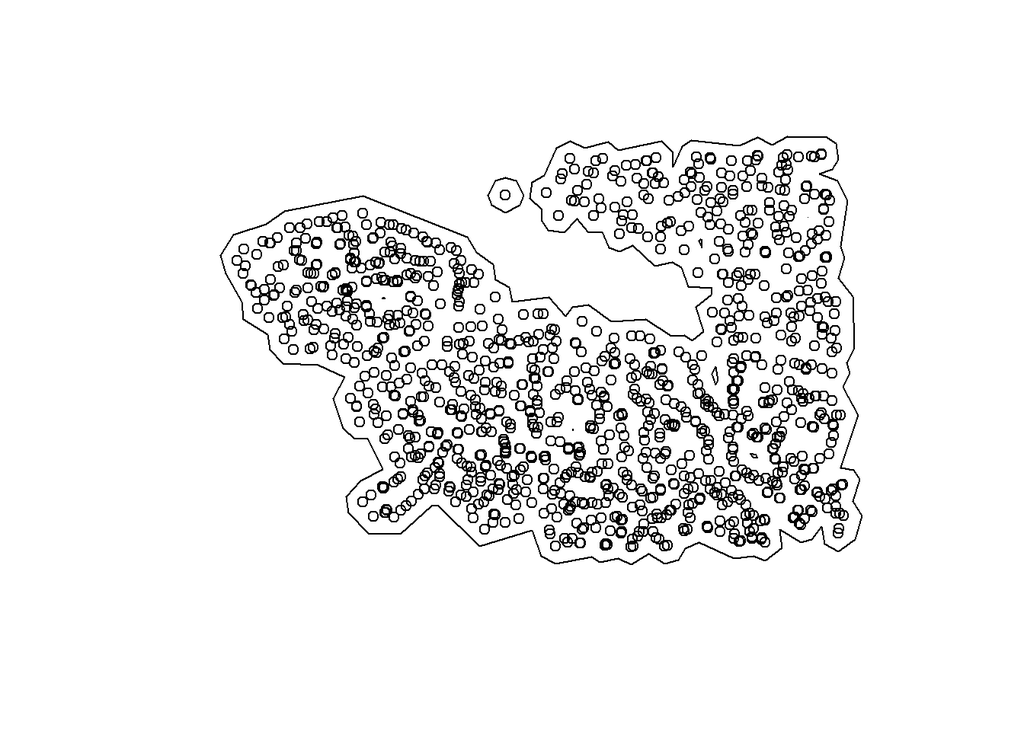

```r
# You have been asked to produce an alkaline probability map over the study area
# To do this, you are going to do some kriging via the krige() function
# This requires a SpatialPixels object which will take a bit of data manipulation to create
# You start by defining a grid, creating points on that grid, cropping to the study region, and then finally converting to SpatialPixels
# On the way, you'll meet some new functions

# GridTopology() defines a rectangular grid. It takes three vectors of length two as inputs
# The first specifies the position of the bottom left corner of the grid
# The second specifies the width and height of each rectangle in the grid, and the third specifies the number of rectangles in each direction

# To ensure that the grid and the study area have the same coordinates, some housekeeping is involved
# SpatialPoints() converts the points to a coordinate reference system (CRS), or projection (different packages use different terminology for the same concept)
# The CRS is created by wrapping the study area in projection(), then in CRS()
# For the purpose of this exercise, you don't need to worry about exactly what these functions do, only that this data manipulation is necessary to align the grid and the study area

# Now that you have that alignment, crop(), as the name suggests, crops the grid to the study area
# Finally, SpatialPixels() converts the raster cropped gridpoints to the equivalent sp object

# The acidity survey data, ca_geo, the missing value index, miss, the variogram, vgm, and the variogram model, v_model, have been pre-defined
# A rough outline of the study area is in an object called geo_bounds

# ca_geo, geo_bounds have been pre-defined
# ls.str()

# Plot the polygon and points
geo_bounds <- readRDS("./RInputFiles/ca_geo_bounds.RDS")
plot(geo_bounds)
points(ca_geo)
```

```r
# Find the corners of the boundary
bbox(geo_bounds)
```

```
##         min       max
## x  537853.4  719269.2
## y 5536290.4 5657400.9
```

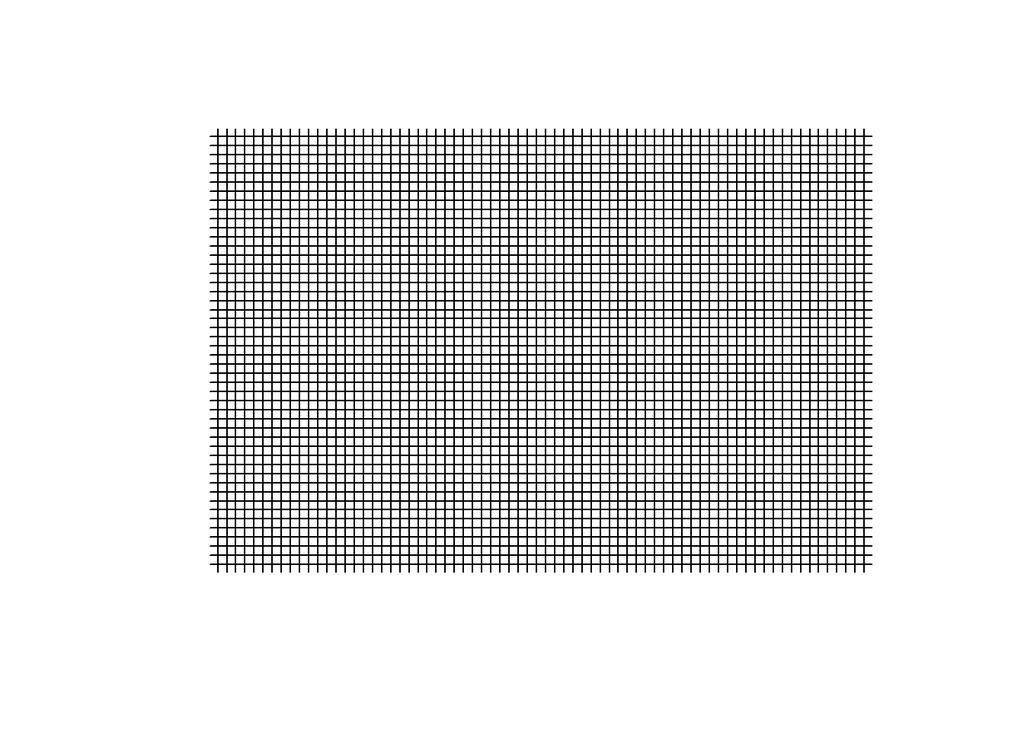

```r
# Define a 2.5km square grid over the polygon extent. The first parameter is
# the bottom left corner.
grid <- GridTopology(c(537853, 5536290), c(2500, 2500), c(72, 48))

# Create points with the same coordinate system as the boundary
gridpoints <- SpatialPoints(grid, proj4string = CRS(raster::projection(geo_bounds)))
plot(gridpoints)
```

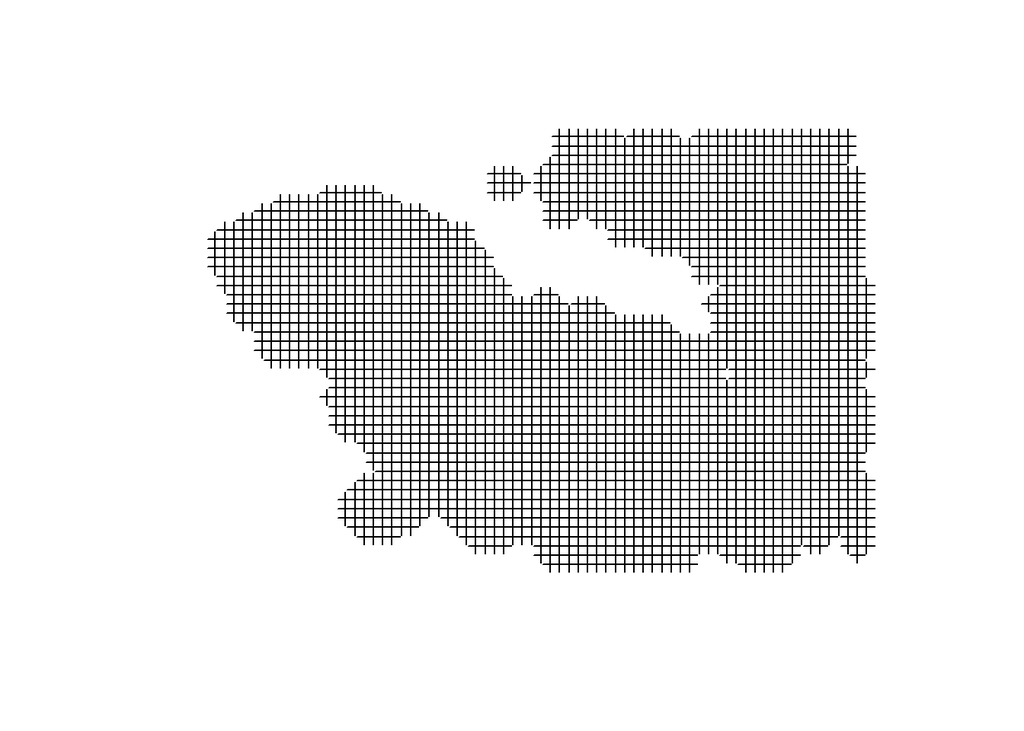

```r
# Crop out the points outside the boundary
cropped_gridpoints <- raster::crop(gridpoints, geo_bounds)
plot(cropped_gridpoints)
```

[figure not shown]

```r
# Convert to SpatialPixels
spgrid <- SpatialPixels(cropped_gridpoints)
coordnames(spgrid) <- c("x", "y")
plot(spgrid)
```

```r
# The spatial pixel grid of the region, spgrid, and the variogram model of pH, v_model have been pre-defined
# spgrid, v_model have been pre-defined
# ls.str()

# Do kriging predictions over the grid
ph_grid <- gstat::krige(pH ~ x + y, ca_geo[!miss, ], newdata = spgrid, model = v_model)
```

```
## [using universal kriging]
```

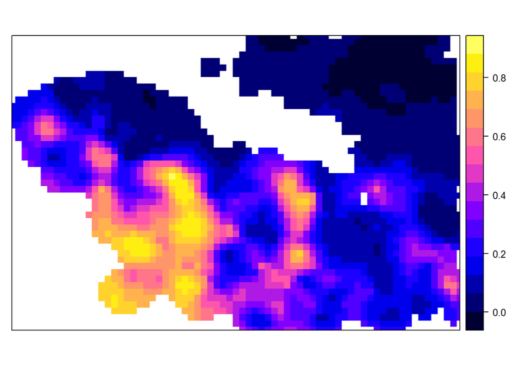

```r
# Calc the probability of pH exceeding 7
ph_grid$pAlkaline <- 1 - pnorm(7, mean = ph_grid$var1.pred, sd = sqrt(ph_grid$var1.var))

# Map the probability of alkaline samples
spplot(ph_grid, zcol = "pAlkaline")
```

```r
# The autoKrige() function in the automap package computes binned variograms, fits models, does model selection, and performs kriging by making multiple calls to the gstat functions you used previously
# It can be a great time-saver but you should always check the results carefully.

# autoKrige() can try several variogram model types
# In the example, you'll use a Matern variogram model, which is commonly used in soil and forestry analyses
# You can see a complete list of available models by calling vgm() with no arguments

# The acidity survey data, ca_geo, and the missing value index, miss, have been pre-defined

# ca_geo, miss are pre-defined
# ls.str()

# Kriging with linear trend, predicting over the missing points
ph_auto <- automap::autoKrige(
  pH ~ x + y,
  input_data = ca_geo[!miss, ],
  new_data = ca_geo[miss, ],
  model = "Mat"
)
```

```
## [using universal kriging]
```

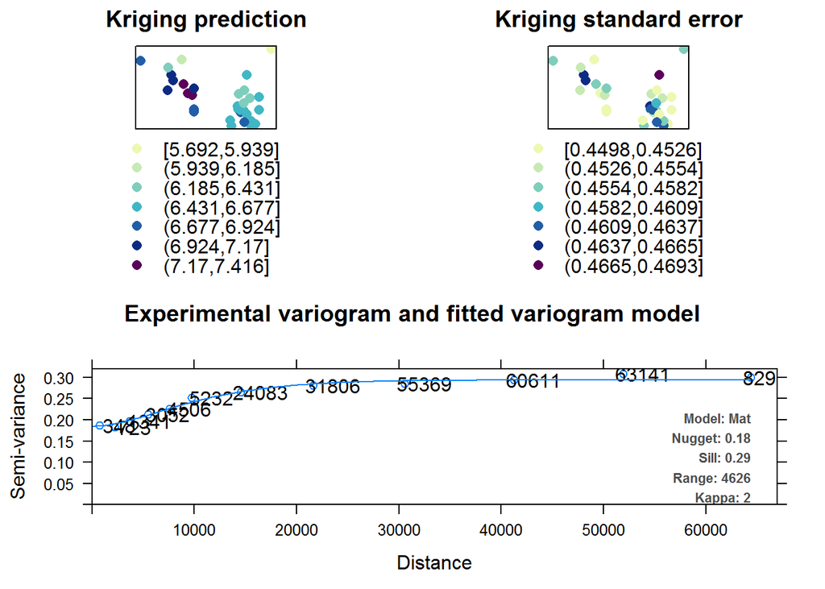

```r
# Plot the variogram, predictions, and standard error
plot(ph_auto)
```

```r
# You can also use autoKrige() over the spgrid grid from the earlier exercise
# This brings together all the concepts that you've learned in the chapter
# That is, kriging is great for predicting missing data, plotting things on a grid is much clearer than plotting individual points, and automatic kriging is less hassle than manual kriging

# The acidity survey data, ca_geo, the missing value index, miss, the spatial pixel grid of the region, spgrid, the manual kriging grid model, ph_grid, and the variogram model of pH, v_model have been pre-defined

# ca_geo, miss, spgrid, ph_grid, v_model are pre-defined
# ls.str()

# Auto-run the kriging
ph_auto_grid <- automap::autoKrige(pH ~ x + y, input_data = ca_geo[!miss, ], new_data = spgrid)
```

```
## [using universal kriging]
```

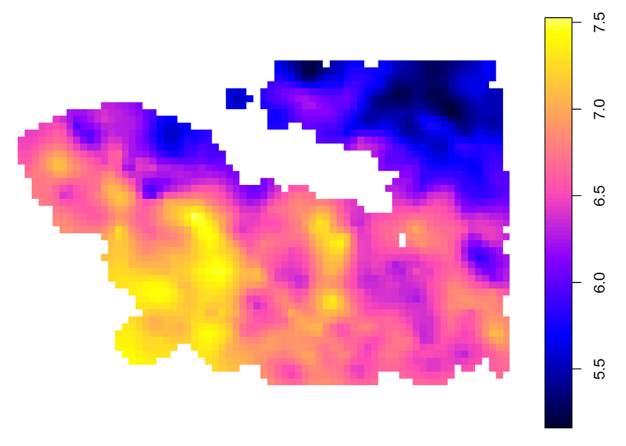

```r
# Remember predictions from manual kriging
plot(ph_grid)
```

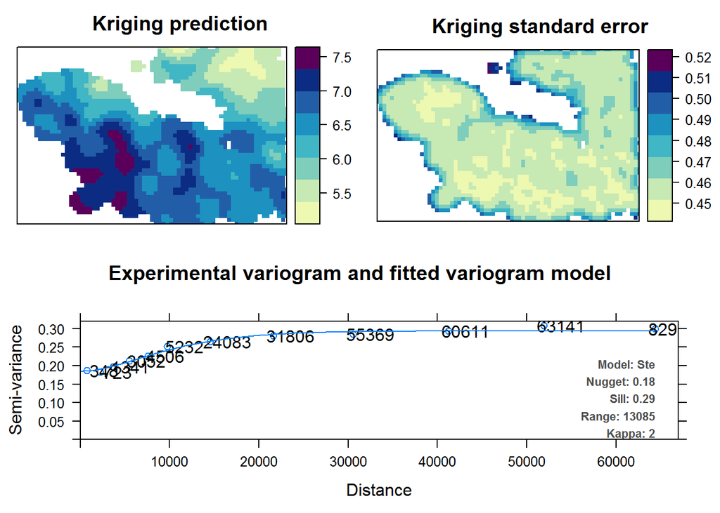

```r
# Plot predictions and variogram fit
plot(ph_auto_grid)
```

```r
# Compare the variogram model to the earlier one
v_model
```

```
##   model     psill    range kappa
## 1   Nug 0.1545116     0.00   0.0
## 2   Ste 0.1442007 14379.29   0.5
```

```r
ph_auto_grid$var_model
```

```
##   model     psill    range kappa
## 1   Nug 0.1846444     0.00     0
## 2   Ste 0.1092281 13085.13     2
```

### *Spatial Analysis in R with sf and raster*

Chapter 1 - Vector and Raster Spatial Data in R

Reading vector and raster data into R:

Getting to know your vector data:

- One of the big innovations of the sf package is that everything is stored as a data frame
  - The data frame has metadata such as coordinate reference system that can be seen using head()
  - The geometry is stored in a list column, which is basically a data frame column that is itself a list
  - Geometry is a special type of list, a simple features list column
- Can call plot() and see one plot for each layer
  - Can call plot(st_geometry()) to plot only the geometry without any of the data

Getting to know your raster data:

- Rasters will be stored as objects of class RasterLayer or RasterBrick
  - The default print option for a raster object is to show all the metadata rather than the data frame
  - The extent() call will give you the minima and maxima for the data
  - The ncell() and nlayers() calls will provide the number of cells and the number of layers
  - The crs() will grab the coordinate reference system
- Note that the raster() and brick() commands do NOT read in the full raster values by default
  - This is because rasters can be extremely large, and memory conservation is a priority
  - The inMemory() call will return a boolean as to whether the data have been read in to memory
  - The plot() and plotRGB() functions are usually good for a quick and dirty look at the data

Example code includes:

```r
# Load the sf package
library(sf)
# Read in the trees shapefile
trees <- st_read("./RInputFiles/ZIP Files/trees/trees.shp")
# Read in the neighborhood shapefile
neighborhoods <- st_read("./RInputFiles/ZIP Files/neighborhoods/neighborhoods.shp")
# Read in the parks shapefile
parks <- st_read("./RInputFiles/ZIP Files/parks/parks.shp")
# View the first few trees
head(trees)
```

```
## Simple feature collection with 6 features and 7 fields
## geometry type:  POINT
## dimension:      XY
## bbox:           xmin: -74.13116 ymin: 40.62351 xmax: -73.80057 ymax: 40.77393
## epsg (SRID):    4326
## proj4string:    +proj=longlat +ellps=WGS84 +no_defs
##   tree_id  nta longitude latitude stump_diam      species      boroname
## 1  558423 QN76 -73.80057 40.67035          0  honeylocust        Queens
## 2  286191 MN32 -73.95422 40.77393          0 Callery pear     Manhattan
## 3  257044 QN70 -73.92309 40.76196          0  Chinese elm        Queens
## 4  603262 BK09 -73.99866 40.69312          0       cherry      Brooklyn
## 5   41769 SI22 -74.11773 40.63166          0       cherry Staten Island
## 6   24024 SI07 -74.13116 40.62351          0    red maple Staten Island
##                     geometry
## 1 POINT (-73.80057 40.67035)
## 2 POINT (-73.95422 40.77393)
## 3 POINT (-73.92309 40.76196)
## 4 POINT (-73.99866 40.69312)
## 5 POINT (-74.11773 40.63166)
## 6 POINT (-74.13116 40.62351)
```

```r
# The term "raster" refers to gridded data that can include satellite imagery, aerial photographs (like orthophotos) and other types
# In R, raster data can be handled using the raster package created by Robert J. Hijmans

# When working with raster data, one of the most important things to keep in mind is that the raw data can be what is known as "single-band" or "multi-band" and these are handled a little differently in R
# Single-band rasters are the simplest, these have a single layer of raster values -- a classic example would be an elevation raster where each cell value represents the elevation at that location
# Multi-band rasters will have more than one layer. An example is a color aerial photo in which there would be one band each representing red, green or blue light.

# Load the raster package
library(raster)
# Read in the tree canopy single-band raster
canopy <- raster("./RInputFiles/ZIP Files/canopy/canopy.tif")

# Read in the manhattan Landsat image multi-band raster
manhattan <- brick("./RInputFiles/ZIP Files/manhattan/manhattan.tif")

# Get the class for the new objects
class(canopy)
```

```
## [1] "RasterLayer"
## attr(,"package")
## [1] "raster"
```

```r
class(manhattan)
```

```
## [1] "RasterBrick"
## attr(,"package")
## [1] "raster"
```

```r
# Identify how many layers each object has
nlayers(canopy)
```

```
## [1] 1
```

```r
nlayers(manhattan)
```

```
## [1] 3
```

```r
# As mentioned in the video, spatial objects in sf are just data frames with some special properties
# This means that packages like dplyr can be used to manipulate sf objects
# In this exercise, you will use the dplyr functions select() to select or drop variables, filter() to filter the data and mutate() to add or alter columns
# Load the dplyr and sf packages
# library(dplyr)
# library(sf)

# Read in the trees shapefile (already read in above)
# trees <- st_read("trees.shp")

# Use filter() to limit to honey locust trees
honeylocust <- trees %>% filter(species == "honeylocust")

# Count the number of rows
nrow(honeylocust)
```

```
## [1] 6418
```

```r
# Limit to tree_id and boroname variables
honeylocust_lim <- honeylocust %>% dplyr::select(tree_id, boroname)

# Use head() to look at the first few records
head(honeylocust_lim)
```

```
## Simple feature collection with 6 features and 2 fields
## geometry type:  POINT
## dimension:      XY
## bbox:           xmin: -73.97524 ymin: 40.67035 xmax: -73.80057 ymax: 40.83136
## epsg (SRID):    4326
## proj4string:    +proj=longlat +ellps=WGS84 +no_defs
##   tree_id boroname                   geometry
## 1  558423   Queens POINT (-73.80057 40.67035)
## 2  548625 Brooklyn POINT (-73.97524 40.68575)
## 3  549439 Brooklyn POINT (-73.94137 40.67557)
## 4  181757 Brooklyn POINT (-73.89377 40.67169)
## 5  379387   Queens  POINT (-73.8221 40.69365)
## 6  383562    Bronx POINT (-73.90041 40.83136)
```

```r
# In this exercise, you will convert the data frame to what's called a tibble with tibble::as_tibble() (Note that dplyr::tbl_df() is now deprecated)
# tibble is loaded in your workspace

# Create a standard, non-spatial data frame with one column
df <- data.frame(a = 1:3)

# Add a list column to your data frame
df$b <- list(1:4, 1:5, 1:10)

# Look at your data frame with head
head(df)
```

```
##   a                             b
## 1 1                    1, 2, 3, 4
## 2 2                 1, 2, 3, 4, 5
## 3 3 1, 2, 3, 4, 5, 6, 7, 8, 9, 10
```

```r
# Convert your data frame to a tibble and print on console
as_tibble(df)
```

```
## # A tibble: 3 x 2
##       a b
##   <int> <list>
## 1     1 <int [4]>
## 2     2 <int [5]>
## 3     3 <int [10]>
```

```r
# Pull out the third observation from both columns individually
df$a[3]
```

```
## [1] 3
```

```r
df$b[3]
```

```
## [[1]]
##  [1]  1  2  3  4  5  6  7  8  9 10
```

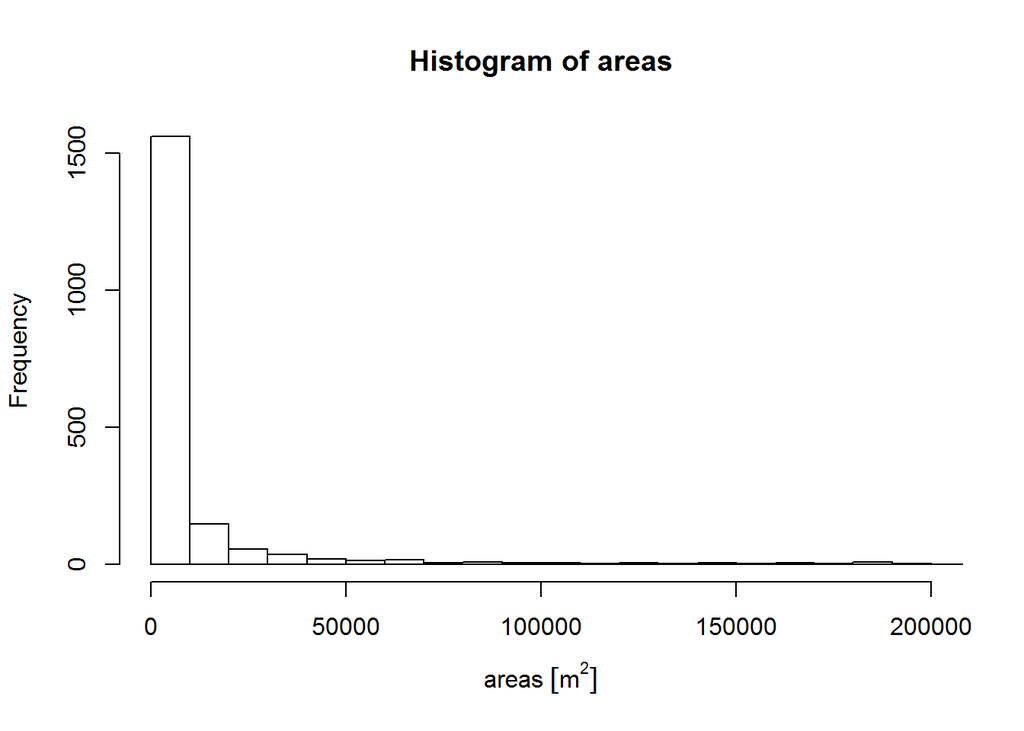

```r
# There are several functions in sf that allow you to access geometric information like area from your vector features
# For example, the functions st_area() and st_length() return the area and length of your features, respectively
# Note that the result of functions like st_area() and st_length() will not be a traditional vector
# Instead the result has a class of units which means the vector result is accompanied by metadata describing the object's units
# you need to either remove the units with unclass()
# or you need to convert val's class to units such as with units(val) <- units(result)

# sf and dplyr are loaded in your workspace

# Read in the parks shapefile (already read in above)
# parks <- st_read("parks.shp")

# Compute the areas of the parks
areas <- st_area(parks)

# Create a quick histogram of the areas using hist
hist(areas, xlim = c(0, 200000), breaks = 1000)
```

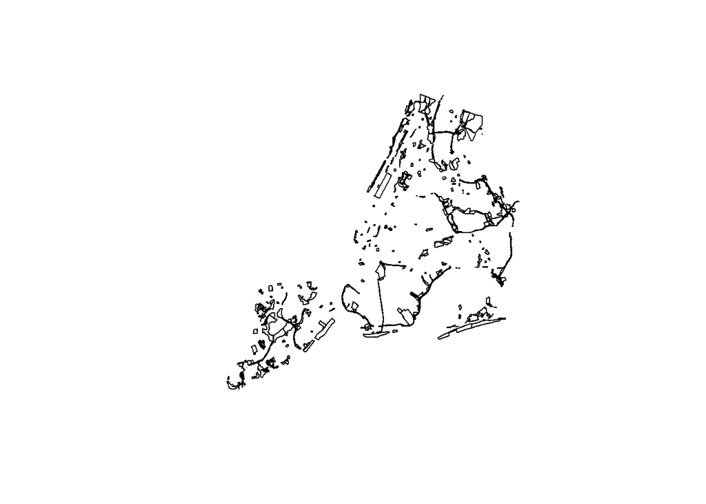

```r
# Filter to parks greater than 30000 (square meters)
big_parks <- parks %>% filter(unclass(areas) > 30000)

# Plot just the geometry of big_parks
plot(st_geometry(big_parks))
```

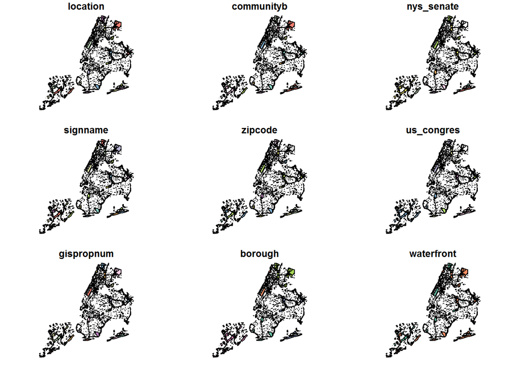

```r
# Plot the parks object using all defaults
plot(parks)
```

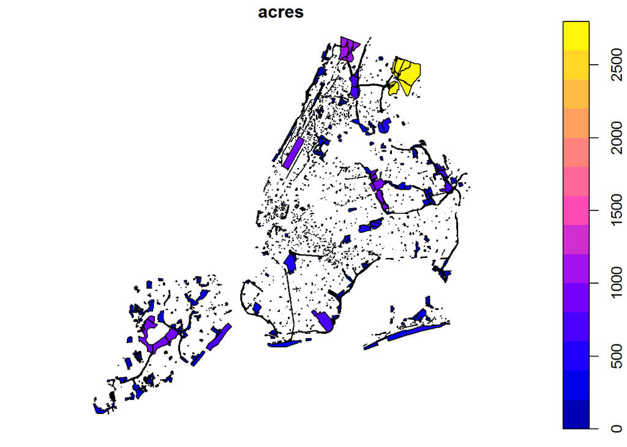

```r
# Plot just the acres attribute of the parks data
plot(parks["acres"])
```

```r
# Create a new object of just the parks geometry
parks_geo <- st_geometry(parks)

# Plot the geometry of the parks data
plot(parks_geo)


# Load the raster package
# library(raster)

# Read in the rasters (done previously)
# canopy <- raster("canopy.tif")
# manhattan <- brick("manhattan.tif")

# Get the extent of the canopy object
extent(canopy)
```

[output not shown]

```
## class       : Extent
## xmin        : 1793685
## xmax        : 1869585
## ymin        : 2141805
## ymax        : 2210805
```

```r
# Get the CRS of the manhattan object
crs(manhattan)
```

```
## CRS arguments:
##  +proj=utm +zone=18 +datum=WGS84 +units=m +no_defs +ellps=WGS84
## +towgs84=0,0,0
```

```r
# Determine the number of grid cells in both raster objects
ncell(manhattan)
```

```
## [1] 619173
```

```r
ncell(canopy)
```

```
## [1] 58190
```

```r
# Raster data can be very big depending on the extent and resolution (grid size)
# In order to deal with this the raster() and brick() functions are designed to only read in the actual raster values as needed
# To show that this is true, you can use the inMemory() function on an object and it will return FALSE if the values are not in memory
# If you use the head() function, the raster package will read in only the values needed, not the full set of values
# The raster values will be read in by default if you perform spatial analysis operations that require it or you can read in the values from a raster manually with the function getValues()

graphics.off()

# Check if the data is in memory
inMemory(canopy)
```

```
## [1] FALSE
```

```r
# Use head() to peak at the first few records
head(canopy)
```

```
##        1     2     3     4     5     6     7     8     9    10    11    12
## 1   0.00 19.35 47.88 17.17 54.27 70.93 81.18 84.23 88.86 87.17 82.27 81.65
## 2   0.00 10.65 58.61 28.77 51.19 53.65 85.29 88.81 89.00 84.59 79.00 87.18
## 3   0.00  0.00 17.26 28.72 49.04 43.84 76.13 83.78 88.30 76.47 84.44 69.35
## 4   0.00  0.96 23.81 64.48 38.24 36.16 79.26 87.02 83.80 70.21 34.33 16.14
## 5   0.00  6.97 38.18 81.83 48.02 52.84 71.18 87.21 76.72 72.90  7.12 47.38
## 6  14.89 31.42 34.17 51.29 85.26 70.05 74.99 83.52 83.98 75.74 41.93 84.72
## 7  65.06 37.87 30.91 23.92 35.21 53.85 85.32 85.59 85.63 76.34 77.72 81.97
## 8  68.95 43.38 37.51 22.02 27.54 72.25 84.80 86.20 86.14 84.44 82.56 67.32
## 9  58.23 33.00 43.03 12.07 19.64 76.00 76.35 76.53 83.94 85.48 83.76 41.86
## 10 46.31 53.63 23.67 10.73 48.16 60.86 63.47 69.98 61.79 55.78 34.47 49.32
##       13    14    15    16    17    18    19    20
## 1  77.95 80.72 64.98 80.05 66.04 34.45 28.03 54.67
## 2  73.62 84.57 72.14 83.08 72.75 13.29 33.37 42.57
## 3  66.02 83.02 72.60 77.81 60.89 49.96 27.29 41.00
## 4  72.36 82.51 72.86 78.84 70.87 30.37 47.14 55.99
## 5  75.38 87.18 74.90 81.76 60.04 24.07 45.37 52.69
## 6  85.36 84.52 65.53 68.28 59.58 52.38 31.21 33.98
## 7  65.10 63.87 48.16 30.90 39.24 29.74  5.78 14.39
## 8   6.58 51.03 21.22 40.49 29.76 22.16  6.76 46.05
## 9   9.47 23.15 50.56 44.56 19.28 32.92 52.94 43.42
## 10  8.55 21.59 55.36 54.16 45.76 47.89 59.27 47.48
```

```r
# Use getValues() to read the values into a vector
vals <- getValues(canopy)

# Use hist() to create a histogram of the values
hist(vals)


# The raster package has added useful methods for plotting both single and multi-band rasters
# For single-band rasters or for a map of each layer in a multi-band raster you can simply use plot()
# If you have a multi-band raster with layers for red, green and blue light you can use the plotRGB() function to plot the raster layers together as a single image

# Plot the canopy raster (single raster)
plot(canopy)

# Plot the manhattan raster (as a single image for each layer)
plot(manhattan)

# Plot the manhattan raster as an image
plotRGB(manhattan)

# raster masks dplyr::select
detach("package:raster")
```

[output not shown]

Chapter 2 - Preparing Layers for Spatial Analysis